# 分類模型（Classification）

郭耀仁

2017-09-01

## 常見的機器學習問題

- 監督式學習
  - 迴歸模型
  - 分類模型（*）
- 非監督式學習
  - 分群模型

## 分類模型

- 也許是目前最廣泛的機器學習應用
- 有為數極多的分類演算法

## 羅吉斯迴歸模型

- 雖然有迴歸兩個字，但其實是個分類器
- 處理二元分類問題
  - Hot dog/Not hot dog
  - 垃圾/普通郵件
  - 詐欺/普通交易

## 羅吉斯迴歸模型（2）

- 氣溫與飲料店**冰紅茶銷量是否超過 70 杯**的關係為何?

Data source: [世界第一簡單統計學](http://www.books.com.tw/products/0010695099)

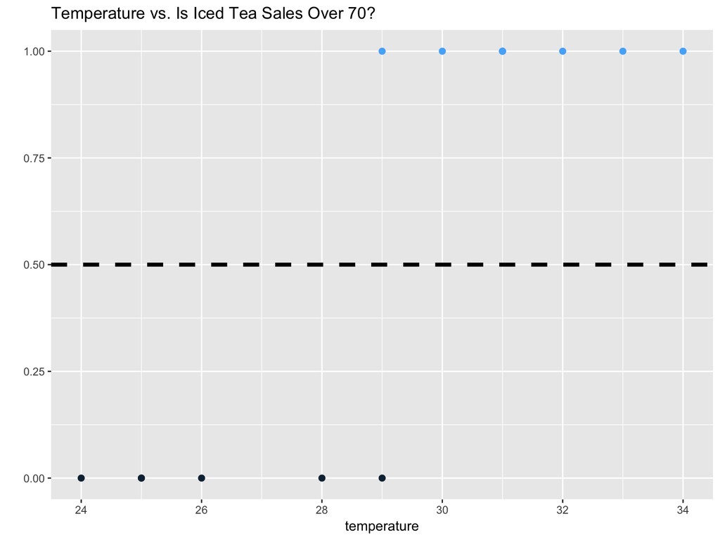

## 羅吉斯迴歸模型（3）

- 我們為何不沿用迴歸模型來做分類模型？
  - 輕易受到離群值影響
  - $h$ 的值域不一定在 0 - 1 之間

## 羅吉斯迴歸模型（4）

- 我們需要將 $h(x) = \theta^{T}x$ 輸出的值域轉換至 $0 \leq h(x) \leq 1$
- 利用 $g$ 函數，也就是 sigmoid function

$$g(z) = \frac{1}{1+e^{-z}}$$
$$h(x) = g(\theta^{T}x) = \frac{1}{1 + e^{-\theta^{T}x}}$$

## 羅吉斯迴歸模型（5）

- 接著我們再做一次轉換，決定 $g(z)$ 輸出的機率該如何轉換至 $\hat{y} \in {\{0, 1\}}$

$$\hat{y} =
\begin{cases}
1 & \quad \text{if } h(x)\geq 0.5\\
0 & \quad \text{otherwise}\\
\end{cases}$$

## 羅吉斯迴歸模型（6）

- 羅吉斯迴歸模型的成本函數：

$$J(h(x), y) =
\begin{cases}
-\log(h(x)) & \quad \text{if } y = 1\\
-\log(1 - h(x)) & \quad \text{if } y = 0\\
\end{cases}$$

## 羅吉斯迴歸模型（7）

- 成本函數示意：

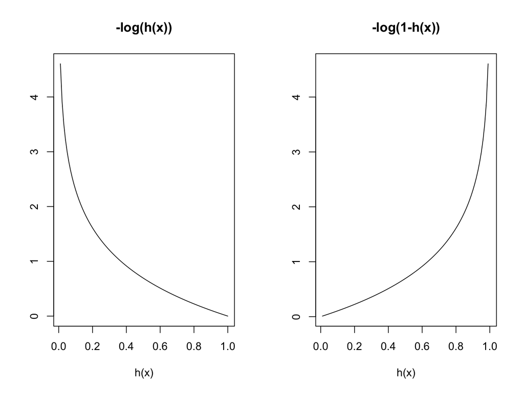

## 羅吉斯迴歸模型（8）

- 梯度遞減

$$J(h(x), y) = -y\log(h(x)) - (1-y)\log(1-h(x))$$

$$J(\theta) = -\frac{1}{m}\sum_{i = 1}^{m}[y\log(h(x))+(1-y)\log(1-h(x))]$$

$$\theta_j := \theta_j - \alpha \frac{\mathrm \partial}{\mathrm \partial \theta_j} J(\theta)$$

## 羅吉斯迴歸模型（9）

- 延伸二元分類到多元分類問題：One-vs-all

$$y \in {\{0, 1, 2\}}$$
$$h^{0}(x) = P(y = 0 \mid x; \theta)$$
$$h^{1}(x) = P(y = 1 \mid x; \theta)$$
$$h^{2}(x) = P(y = 2 \mid x; \theta)$$
$$\text{prediction:}\;\;max(h^{0}(x), h^{1}(x), h^{2}(x))$$

## 羅吉斯迴歸模型（10）

- 將資料集切割為訓練、測試

```r
# train_test_split()
train_test_split <- function(x, train_size = 0.7){
  n_row <- nrow(x)
  shuffled_order <- sample(1:n_row)
  x_shuffled <- x[shuffled_order, ]
  cut_point <- round(n_row * train_size)
  train_data <- x_shuffled[1:cut_point, ]
  test_data <- x_shuffled[(cut_point + 1):n_row,]
  return(list(
    train = train_data,
    test = test_data
  ))
}
```

## 羅吉斯迴歸模型（11 ）

- 使用 `glm()` 函數

```r
temperature <- c(29, 28, 34, 31, 25, 29, 32, 31, 24, 33, 25, 31, 26, 30)
iced_tea_sales <- c(77, 62, 93, 84, 59, 64, 80, 75, 58, 91, 51, 73, 65, 84)
iced_tea_sales_category <- ifelse(iced_tea_sales > 70, 1, 0)
iced_tea_df <- data.frame(temperature, iced_tea_sales, iced_tea_sales_category)

# Splitting
iced_tea_train_test <- train_test_split(iced_tea_df)
train <- iced_tea_train_test$train
test <- iced_tea_train_test$test

# Modeling
logit_fit <- glm(iced_tea_sales_category ~ temperature, data = train, family = "binomial")

# Predicting
y_hat <- predict(logit_fit, newdata = test, type = "response")
y_hat <- ifelse(y_hat > 0.5, 1, 0)
```

## 羅吉斯迴歸模型（11 ）

- 使用[混淆矩陣](https://en.wikipedia.org/wiki/Confusion_matrix)來評估分類模型的績效

```r
conf_mat <- table(y_hat, test$iced_tea_sales_category)
acc <- sum(diag(conf_mat)) / sum(conf_mat)
acc
```

## 其他的分類器

- 羅吉斯迴歸通常用來處理線性可分的資料

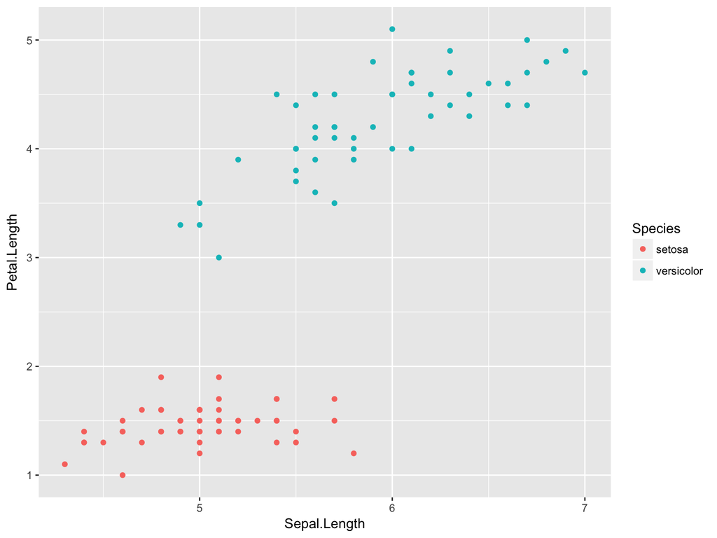

## 其他的分類器（2）

- 如果是非線性可分的資料，通常使用其他的分類器

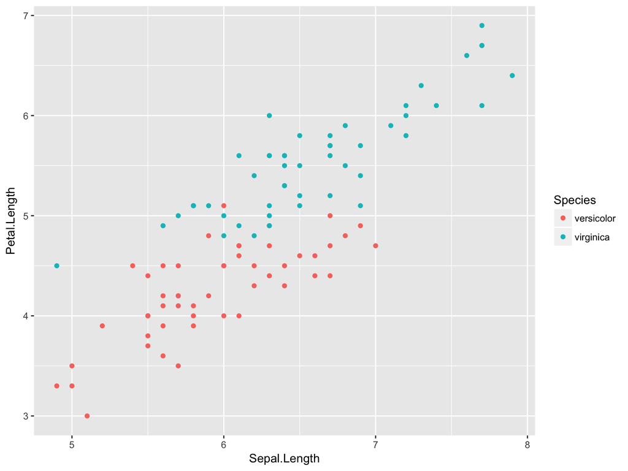

## 其他的分類器（3）

- 決策樹分類器（`rpart` 套件）
- 隨機森林分類器（`randomForest` 套件）
- KNN 演算法
- 支援向量機
- 神經網絡
- …etc.